# R Notebook

```r
library(tidyverse)
library(CodeClanData)
backpacks <- backpack
```

In all plots you make, ensure your labels are appropriate. You also must write down a short summary of what each plot tells you in order to meet MVP.

# MVP

Question 1.

Load in the libraries you need, and look at the backpack data. Take note of variable names and dimensions.

Contains backpack weight, body weight, what I assume to be a ratio between these two, what looks like a logical column for back problems, the person’s major, their year (at university/school?), sex, status (which might refer to Undergraduate and Graduate) and a variable called units which could be how many subjects they are studying.

I assume the weights are given in pounds.

Units range from 0-19. Year from 0-6. Majors contains 41 values which are organised as factors.

```r
unique(backpacks$major)
```

```
 [1] Bio         Philosophy  GRC         CSC         EE          History
 [7] CM          ARCE        Bus         ME          CPE         CS
[13] LS          CE          AGB         Mate        Poli Sci    Aero Eng.
[19] Soc. Sci.   MLL         Math        Psych       IT          Psy
[25] SOCS        Nut.        SPC         CD          Econ        Vocal Music
[31] Kine        Act.        Nutrition   Aero        Phys        Pols
[37] IE          MFGE        Arch        APIO        AERO
41 Levels: Act. Aero AERO Aero Eng. AGB APIO ARCE Arch Bio Bus CD CE CM CPE ... Vocal Music
```

Question 2.

What is the distribution of backpack weights that students are carrying? Choose an appropriate graph to show the distribution.

This line graph shows theferquency of the occurence of a weight of backpack in the dataset. It shows that backpack weight has a standard distribution centring just under 10 pounds and tailing on the heavy side.

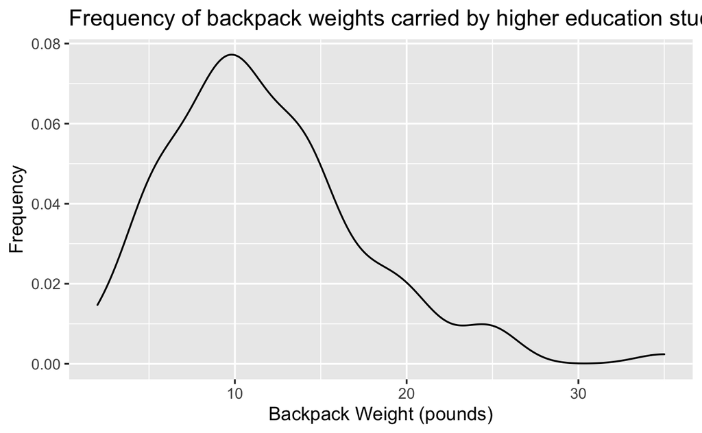

Question 3.

Are there differences in backpack weight between sex?

This graph shows the frequency of different backpack weights split by the student’s gender. The backpack weight for women trends slightly smaller than it does for men centring just below 10 pounds and tailing on the heavy side. The backpack weight for men trends slightly larger than womens and centres at 10 pounds with a longer tail to the heavier side.

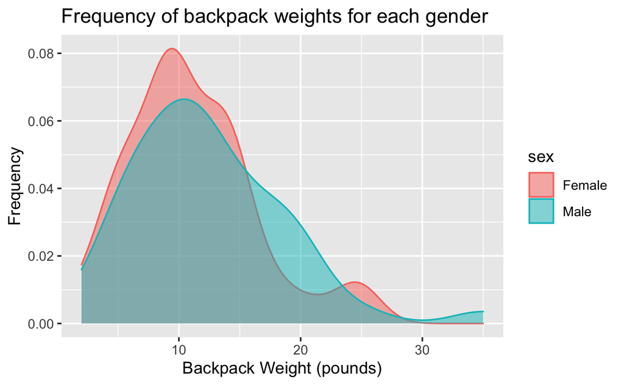

Question 4.

What is the relationship between body weight and backpack weight?

This chart shows a smoothed line comparing the weight of a backpack to the average weight of people who carry that size of backpack. This shows us that the relationship between body size and backpackweight has a positive correlation which is most significant in body weights of less than 150 pounds and over 160. We can also see that students weighing 150 pounds carry a range of backpack sizes, so the relationship between body weight and backpack weight is not easily described by a straight line.

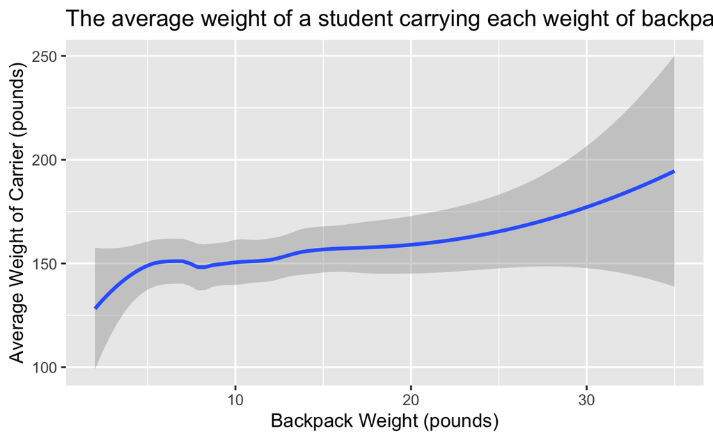

Question 5.

Is this relationship different between men and women? Choose an appropriate plot and interpret your findings.

This graph shows the relationship between student weight and backpack weight for male and female students. The relationship between the two variables is similar for men and for women, with both the body and backpack weight in this dataset lower for women than for men.

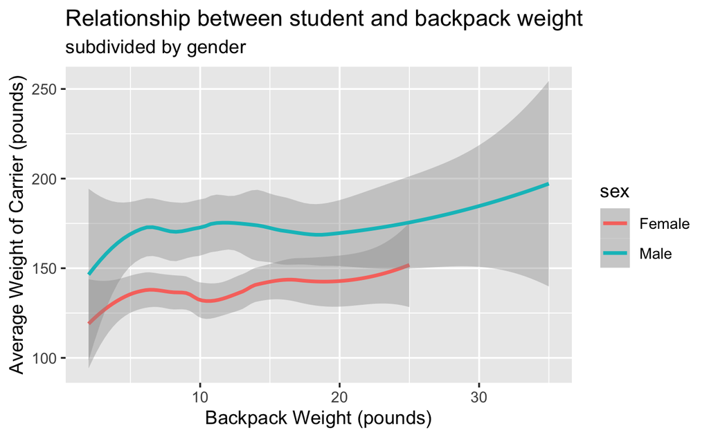

Question 6.

What proportion of students report back pain?

number of students reporting back pain divided by total number of students * 100

32 of our 100 students, or 32%, report experiencing back problems.

| proportion_experiencing_backpain |
| --- |
| 32 |

Question 7.

Is this proportion different between men and women?

Yes, 43% of the women report back pain compared to just under 18% of men.

```r
backpacks %>%
  group_by(sex) %>%
  summarise(proportion_experiencing_backpain_as_a_percent = sum(back_problems) / n() * 100)
```

| sex | proportion_experiencing_backpain_as_a_percent |
| --- | --- |
| Female | 43.63636 |
| Male | 17.77778 |

Question 8.

Now you’ve investigated your data separately, create plots to describe the relationship between backpack weight, body weight, gender and reported backpain.

Try both backpack_weight and body_weight as well as the ratio.

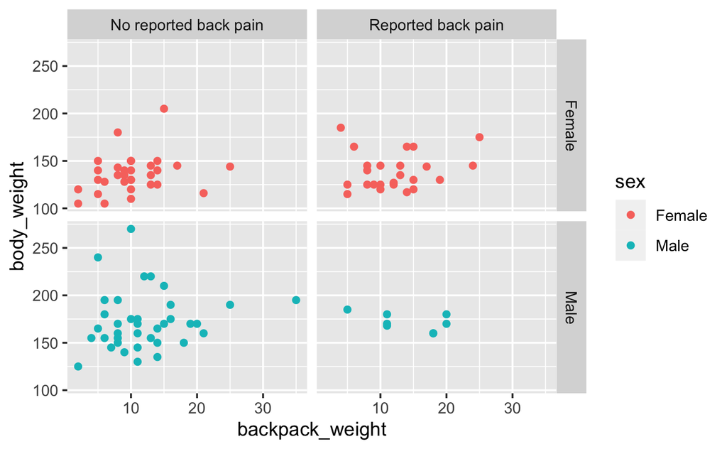

Hint: faceting would be useful here.

3 Extensions

Question 1.

Does reported backpain differ across the year groups? Ignore year 0 in your data.

Question 2.

Is there a difference between how heavy the bags those in different years carry?